# Assessing Treatment Effects of TFD725 for Non-small Cell Lung Cancer

Note: The report might be shown to the class as examples if it is done well very or very badly, with your identity redacted.

# 1 Introduction

This document demonstrates a basic template for the final report for STA 207, Winter 2020. Depending on the project, you may not need to include all subsections in your report. You are encouraged to write the report in other formats if you find them more effective for your project.

Note: You may use this `.rmd` file to draft your final report. However, this report contains unpolished tables and figures, and results without interpretation, which should not be presented in your final report. A team should expect to fail the class if the submitted report is not significantly better than this one. To be specific, two independent reviewers review this report to be 1/5 and 2/5 (i.e., 2/10 and 4/10 in our scale), respectively.

You may skip the section on analysis plan in the course projects.

## 1.1 Background

Note: Discuss the basic background of this project here, even if you pick one of the three provided data sets. In particular, you are expected to briefly comment on the importance of this analysis, and explain the goals of this project. For instance, you can write two short paragraphs as follows.

In this project, we analyze the data from a Phase II study of patients with non-small cell lung cancer. The double-blind randomized multicenter clinical trials studied whether using docetaxel and TFD725 would prolong survival of patients diagnosed with NSCLC compared to using only docetaxel alone.

The primary scientific question of interest is whether second line chemotherapy using docetaxel and TFD725 associated with prolonged survival compared to docetaxel alone. In this project, we would also like to estimate the survival rate of patients over the period of study given the baseline covariates. In addition, we will test whether the treatment effects, if any, depend on the regions of patients, indicator that patient had an abnormal LDF level, or indicator that patient had an abnormal alkaline phoshatase level.

## 1.2 Statistical questions of interest

Note: Translate the scientific goals into statistical questions that can be answered with appropriate statistical analysis on the given data.

To answer the primary scientific question of interest, we propose to fit a linear regression with the observation time (from randomization) as the response and the indicator of region, age, indicator of gender, indicator of advanced stage, indicator for whether patient had an abnormal LDF level at time of randomization, indicator whether patient had an abnormal alkaline phoshatase level at time of randomization, and patient’s performance on ECOG scale as covariates. To answer the secondary questions of interest, we will use the Cox proportional hazard model to estimate the survival rate, and we will add interaction terms between the treatment indicator and the regions of patients, indicator that patient had an abnormal LDF level, or indicator that patient had an abnormal alkaline phoshatase level.

# 2 Analysis Plan

Note: It is best practice to write down the statistical analysis plan before analyzing data. This can significantly improve the rigorousity and reproducibility of the analysis, and avoid false discovery. This section should just be an extended version of your initial proposal. It is often inevitable that one may need to alter the analysis plan for unexpected features in the data. However, detailed documentation of the changes will shed light on unique features of the data set and help future analysis.

## 2.1 Population and study design

Note: Discuss the target population of this analysis, and how the study is design to collect representative data for this population.

## 2.2 Statistical Analysis

### 2.2.1 Descriptive Analysis

Note: Describe the descriptive analysis you plan to conduct on the data set. The goal of the descriptive analysis is to provide an overview of the data set (and the study that collects the data) beforing diving into the analysis.

We will summarize the distribution of each variables for patients in the treatment group and the control group. Based on the summary statistics, we will evaluate whether the randomization is successful. To be specific, all summary statistics of baseline variables should be similar between the treatment and control groups.

We will estimate the survival function of patients in the treatment and control groups using Kaplan-Meier estimates, without adjusting for any covariates. Furthermore, we will summarize the distribution of observation time and the patients’ status at the end of study in groups defined by treatment, regions of patients, indicator that patient had an abnormal LDF level, or indicator that patient had an abnormal alkaline phoshatase level.

### 2.2.2 Main Analysis

Note: Describe the analysis you plan to conduct to answer the questions of interest. Remember to rename the section title to fit the actual analysis you propose, e.g., inferential analysis, clustering, prediction model, etc. For instance, in this report, this section should explain

- Detailed model specification of linear regression model.
- Description of the Cox proportional hazard model.
- Description of the model with interactions.

Furthermore, this section should also explain how you plan to interpret the conclusion—this is a convention for the analysis of clinical trials, which may not apply to other data science projects.

### 2.2.3 Sensitivity Analysis

Note: Describe additional analysis you plan to conduct to complement the main analysis. This section should include analysis to show that the results you get are not sensitive to the model choices or assumptions. You can also conduct analysis to account for features in the data you have not foreseen.

# 3 Results

Note: In this template, we present the unpolished tables and figures generated with generic `r` functions, and we skip all interpretation of the analysis results and the sensitivity analysis. You can adapt any functions in this section in your report.

## 3.1 Descriptive Analysis

Note: There are many ways to automatically generate summary tables in `R`, of which many would even generate html or latex tables. In this template, we will use the package `qwraps2` as an example ([link](https://cran.r-project.org/web/packages/qwraps2/vignettes/summary-statistics.html)).

|  | tx: 0 (N = 90) | tx: 1 (N = 98) |
| --- | --- | --- |
| **europe** |  |  |
| minimum | 0 | 0 |
| median (IQR) | 0.00 (0.00, 0.00) | 0.00 (0.00, 0.00) |
| mean (sd) | 0.19 $\pm$ 0.39 | 0.17 $\pm$ 0.38 |
| maximum | 1 | 1 |
| **age** |  |  |
| minimum | 50 | 46 |
| median (IQR) | 61.00 (58.00, 63.00) | 60.00 (57.00, 64.00) |
| mean (sd) | 60.51 $\pm$ 4.79 | 60.38 $\pm$ 5.41 |
| maximum | 75 | 71 |
| **male** |  |  |
| minimum | 0 | 0 |
| median (IQR) | 1.00 (0.00, 1.00) | 1.00 (0.00, 1.00) |
| mean (sd) | 0.52 $\pm$ 0.50 | 0.58 $\pm$ 0.50 |
| maximum | 1 | 1 |
| **advdis** |  |  |
| minimum | 0 | 0 |
| median (IQR) | 1.00 (0.00, 1.00) | 1.00 (0.00, 1.00) |
| mean (sd) | 0.66 $\pm$ 0.48 | 0.60 $\pm$ 0.49 |
| maximum | 1 | 1 |
| **response** |  |  |
| minimum | 0 | 0 |
| median (IQR) | 1.00 (0.00, 1.00) | 1.00 (0.00, 1.00) |
| mean (sd) | 0.57 $\pm$ 0.50 | 0.57 $\pm$ 0.50 |
| maximum | 1 | 1 |
| **durdis** |  |  |
| minimum | 3 | 3 |
| median (IQR) | 10.00 (7.00, 13.00) | 10.00 (7.00, 13.00) |
| mean (sd) | 10.23 $\pm$ 4.34 | 10.39 $\pm$ 4.77 |
| maximum | 27 | 31 |
| **abnLDH** |  |  |
| minimum | 0 | 0 |
| median (IQR) | 0.00 (0.00, 0.00) | 0.00 (0.00, 0.00) |
| mean (sd) | 0.18 $\pm$ 0.38 | 0.09 $\pm$ 0.29 |
| maximum | 1 | 1 |
| **abnAlkphos** |  |  |
| minimum | 0 | 0 |
| median (IQR) | 0.00 (0.00, 1.00) | 0.00 (0.00, 0.00) |
| mean (sd) | 0.32 $\pm$ 0.47 | 0.19 $\pm$ 0.40 |
| maximum | 1 | 1 |
| **ECOG** |  |  |
| minimum | 0 | 0 |
| median (IQR) | 1.00 (0.25, 1.00) | 1.00 (0.00, 1.00) |
| mean (sd) | 0.80 $\pm$ 0.52 | 0.69 $\pm$ 0.55 |
| maximum | 2 | 2 |
| **obstime** |  |  |
| minimum | 56 | 59 |
| median (IQR) | 372.00 (307.25, 481.00) | 414.00 (314.00, 496.00) |
| mean (sd) | 375.81 $\pm$ 124.44 | 400.63 $\pm$ 129.60 |
| maximum | 607 | 615 |
| **death** |  |  |
| minimum | 0 | 0 |
| median (IQR) | 1.00 (1.00, 1.00) | 1.00 (0.00, 1.00) |
| mean (sd) | 0.80 $\pm$ 0.40 | 0.69 $\pm$ 0.46 |
| maximum | 1 | 1 |
| **survival.past.400** |  |  |
| minimum | 0 | 0 |
| median (IQR) | 0.00 (0.00, 1.00) | 1.00 (0.00, 1.00) |
| mean (sd) | 0.42 $\pm$ 0.50 | 0.56 $\pm$ 0.50 |
| maximum | 1 | 1 |

Note: Draw the Kaplan-Meier curve with no adjusted variables [Link](https://rviews.rstudio.com/2017/09/25/survival-analysis-with-r/).

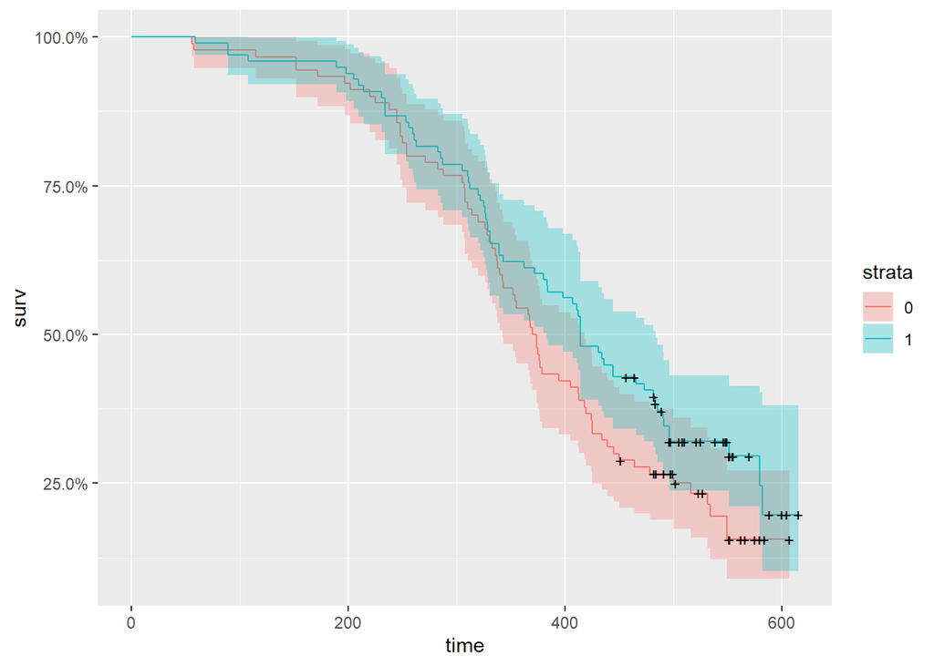

|  | europe: 0 (N = 81) | europe: 1 (N = 17) | europe: 0 (N = 73) | europe: 1 (N = 17) |
| --- | --- | --- | --- | --- |
| **obstime** |  |  |  |  |
| minimum | 59 | 198 | 56 | 58 |
| median (IQR) | 414 (310.00, 496.00) | 407 (339.00, 490.00) | 374 (314.00, 482.00) | 320 (283.00, 451.00) |
| mean (sd) | 398.35 $\pm$ 133.42 | 411.53 $\pm$ 112.58 | 380.51 $\pm$ 121.85 | 355.65 $\pm$ 137.07 |
| maximum | 615 | 570 | 607 | 579 |
| **survival.past.400** |  |  |  |  |
| minimum | 0 | 0 | 0 | 0 |
| median (IQR) | 1 (0.00, 1.00) | 1 (0.00, 1.00) | 0 (0.00, 1.00) | 0 (0.00, 1.00) |
| mean (sd) | 0.57 $\pm$ 0.50 | 0.53 $\pm$ 0.51 | 0.42 $\pm$ 0.50 | 0.41 $\pm$ 0.51 |
| maximum | 1 | 1 | 1 | 1 |

|  | abnLDH: 0 (N = 89) | abnLDH: 1 (N = 9) | abnLDH: 0 (N = 74) | abnLDH: 1 (N = 16) |
| --- | --- | --- | --- | --- |
| **obstime** |  |  |  |  |
| minimum | 59 | 205 | 115 | 56 |
| median (IQR) | 431 (325.00, 497.00) | 283 (234.00, 414.00) | 378.00 (328.50, 489.25) | 265.50 (167.00, 352.75) |
| mean (sd) | 407.53 $\pm$ 128.89 | 332.44 $\pm$ 123.15 | 399.20 $\pm$ 109.09 | 267.62 $\pm$ 137.04 |
| maximum | 615 | 546 | 607 | 551 |
| **survival.past.400** |  |  |  |  |
| minimum | 0 | 0 | 0 | 0 |
| median (IQR) | 1 (0.00, 1.00) | 0 (0.00, 1.00) | 0.00 (0.00, 1.00) | 0.00 (0.00, 0.00) |
| mean (sd) | 0.58 $\pm$ 0.50 | 0.33 $\pm$ 0.50 | 0.47 $\pm$ 0.50 | 0.19 $\pm$ 0.40 |
| maximum | 1 | 1 | 1 | 1 |

|  | abnAlkphos: 0 (N = 79) | abnAlkphos: 1 (N = 19) | abnAlkphos: 0 (N = 61) | abnAlkphos: 1 (N = 29) |
| --- | --- | --- | --- | --- |
| **obstime** |  |  |  |  |
| minimum | 59 | 89 | 56 | 172 |
| median (IQR) | 444 (327.50, 506.50) | 320 (256.50, 424.00) | 376 (288.00, 497.00) | 355 (328.00, 413.00) |
| mean (sd) | 415.67 $\pm$ 127.52 | 338.11 $\pm$ 122.18 | 381.31 $\pm$ 138.95 | 364.24 $\pm$ 87.43 |
| maximum | 615 | 582 | 607 | 566 |
| **survival.past.400** |  |  |  |  |
| minimum | 0 | 0 | 0 | 0 |
| median (IQR) | 1 (0.00, 1.00) | 0 (0.00, 1.00) | 0 (0.00, 1.00) | 0 (0.00, 1.00) |
| mean (sd) | 0.61 $\pm$ 0.49 | 0.37 $\pm$ 0.50 | 0.46 $\pm$ 0.50 | 0.34 $\pm$ 0.48 |
| maximum | 1 | 1 | 1 | 1 |

## 3.2 Inferential Analysis

Table 3: Results of multiple linear regression

|  | Estimate | Std. Error | t value | Pr(>\|t\|) |
| --- | --- | --- | --- | --- |
| (Intercept) | 498.804 | 115.13 | 4.332 | 0.000 |
| tx | 9.954 | 17.60 | 0.566 | 0.572 |
| europe | 0.948 | 21.19 | 0.045 | 0.964 |
| age | -1.085 | 1.82 | -0.597 | 0.551 |
| male | -33.271 | 17.63 | -1.887 | 0.061 |
| advdis | -23.608 | 18.64 | -1.267 | 0.207 |
| response | 37.537 | 18.09 | 2.075 | 0.039 |
| abnLDH | -100.813 | 27.11 | -3.719 | 0.000 |
| abnAlkphos | -36.141 | 19.83 | -1.823 | 0.070 |
| as.factor(ECOG)1 | -22.339 | 19.27 | -1.159 | 0.248 |
| as.factor(ECOG)2 | -17.431 | 41.65 | -0.418 | 0.676 |

Table 4: Results of Cox proportional hazard model

|  | coef | exp(coef) | se(coef) | z | Pr(>\|z\|) |
| --- | --- | --- | --- | --- | --- |
| tx | -0.135 | 0.874 | 0.176 | -0.768 | 0.442 |
| europe | 0.019 | 1.019 | 0.236 | 0.079 | 0.937 |
| age | 0.003 | 1.003 | 0.016 | 0.186 | 0.852 |
| male | 0.412 | 1.509 | 0.179 | 2.304 | 0.021 |
| advdis | 0.323 | 1.381 | 0.210 | 1.540 | 0.124 |
| response | -0.368 | 0.692 | 0.181 | -2.030 | 0.042 |
| abnLDH | 0.930 | 2.535 | 0.254 | 3.669 | 0.000 |
| abnAlkphos | 0.597 | 1.817 | 0.201 | 2.977 | 0.003 |
| as.factor(ECOG)1 | 0.267 | 1.306 | 0.194 | 1.374 | 0.169 |
| as.factor(ECOG)2 | 0.467 | 1.595 | 0.438 | 1.065 | 0.287 |

Check if adding more interactions will change results.

Table 5: Results of Cox proportional hazard model with interaction terms

|  | coef | exp(coef) | se(coef) | z | Pr(>\|z\|) |
| --- | --- | --- | --- | --- | --- |
| tx | -2.706 | 0.067 | 2.162 | -1.252 | 0.211 |
| europe | -0.256 | 0.774 | 0.347 | -0.739 | 0.460 |
| age | -0.019 | 0.981 | 0.027 | -0.719 | 0.472 |
| male | 0.338 | 1.402 | 0.249 | 1.355 | 0.175 |
| advdis | -0.017 | 0.983 | 0.288 | -0.059 | 0.953 |
| response | -0.445 | 0.641 | 0.252 | -1.765 | 0.078 |
| abnLDH | 1.096 | 2.993 | 0.330 | 3.319 | 0.001 |
| abnAlkphos | 0.470 | 1.600 | 0.269 | 1.746 | 0.081 |
| as.factor(ECOG)1 | 0.235 | 1.265 | 0.202 | 1.162 | 0.245 |
| as.factor(ECOG)2 | 0.355 | 1.426 | 0.453 | 0.784 | 0.433 |
| tx:europe | 0.514 | 1.672 | 0.480 | 1.070 | 0.284 |
| tx:age | 0.031 | 1.031 | 0.035 | 0.884 | 0.377 |
| tx:male | 0.029 | 1.030 | 0.368 | 0.080 | 0.936 |
| tx:advdis | 0.653 | 1.921 | 0.422 | 1.546 | 0.122 |
| tx:response | 0.168 | 1.183 | 0.375 | 0.449 | 0.653 |
| tx:abnLDH | -0.115 | 0.892 | 0.532 | -0.215 | 0.829 |
| tx:abnAlkphos | 0.268 | 1.308 | 0.390 | 0.688 | 0.491 |

The likelihood ratio test for the two models yields a p-value of 0.613.

## 3.3 Sensitivity analysis

Note: Show the results of the sensitivity analysis in this section. You can also discuss any new analysis that are not in the interim report.

# 4 Discussion

Note: Discuss the limitations of the presented projects, and comment on how this project enlightens future research or analysis.